# Schanning Final Project

Sjana Schanning

22 May, 2020

```r
setwd ("/cloud/project")
library(tidyverse)
```

```r
trees <- read.csv("WI_SAPS3.csv")%>%
  mutate(CCLCD=plyr::mapvalues(CCLCD,from=c("1","2","3","4","5"),to=c("Open Grown","Dominant","Co-dominant","Intermediate","Overtopped")))%>%
  mutate(CCLCD=factor(CCLCD,levels=c("Open Grown","Dominant","Co-dominant","Intermediate","Overtopped")))%>%
  drop_na(CCLCD)
str(trees)
head(trees)

trees2 <- read.csv("WI_SAPS3.csv")%>%
  mutate(CCLCD=plyr::mapvalues(CCLCD,from=c("1","2","3","4","5"),to=c("Open Grown","Dominant","Co-dominant","Intermediate","Overtopped")))%>%
  mutate(CCLCD=factor(CCLCD,levels=c("Open Grown","Dominant","Co-dominant","Intermediate","Overtopped")))%>%
  drop_na(CCLCD)%>%
  filter(SPCD=="black spruce")
str(trees2)
head(trees2)

aspen<-read.csv("aspen.csv")%>%
  mutate(INVYR=factor(INVYR))%>%
  filter(INVYR==c("2000","2005","2010","2015"))
```

```
#R> Warning in `==.default`(INVYR, c("2000", "2005", "2010", "2015")): longer object
#R> length is not a multiple of shorter object length
```

```
#R> Warning in is.na(e1) | is.na(e2): longer object length is not a multiple of
#R> shorter object length
```

```r
str(aspen)
head(aspen)
```

# Let’s Save Ourselves Some Time

In 2016 the U.S. Forest Service Forest Inventory and Analysis (FIA) project added sapling height to its repertoire of forest research data collected. Tree heights are consistently one of the most time consuming individual pieces of data collected and the requirement has added considerably to total data collection time. The time investment since 2016 has resulted in significant data and the potential for its use to model sapling heights for future inventories should be considered. The plot below shows the data collected in Wisconsin from five species of saplings during 2016, 2017, 2018 and 2019, and the Hours of Effort required to sample height.

“Hours of Effort” is based on an estimate of 25.8 seconds per sapling required to measure height. This estimate was derived by averaging the individual estimates of 21 experienced field employees regarding the number of seconds/sapling required to measure height.

FIA data is public and is available on-line at https://www.fia.fs.fed.us/tools-data/index.php

```r
trees_sum1<-trees%>%
  group_by(SPCD)%>%
  summarize(n=n())
trees_sum1
```

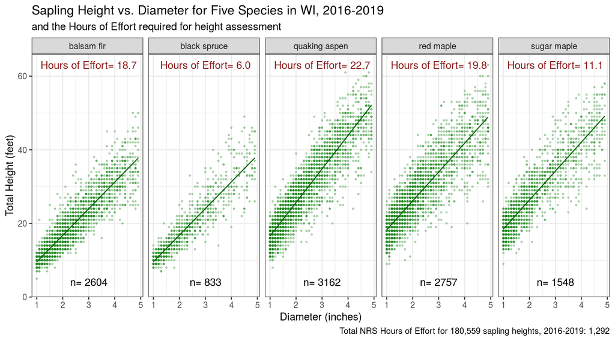

```r
ggplot()+
  geom_point(data=trees,mapping=aes(x=DIA,y=HT),size=.5,shape=21,fill="forestgreen",color="forestgreen",alpha=.3)+
  facet_grid(.~SPCD)+
  scale_x_continuous(name="Diameter (inches)")+
  scale_y_continuous(name="Total Height (feet)")+
  theme_bw()+
  theme(legend.position="none")+
  geom_smooth(data=trees,mapping=aes(x=DIA,y=HT),method="lm",color="darkgreen",se=FALSE,size=.5)+
  geom_text(data=trees_sum1, mapping=aes(x=3,y=3,label=paste("n=",n),vjust="bottom"))+
  geom_text(data=trees_sum1, mapping=aes(x=3,y=62,label=paste("Hours of Effort=",sprintf("%.01f",(25.8/60)*n/60))),vjust="bottom",color="firebrick4")+
   labs(title="Sapling Height vs. Diameter for Five Species in WI, 2016-2019",
       subtitle="and the Hours of Effort required for height assessment",
       caption="Total NRS Hours of Effort for 180,559 sapling heights, 2016-2019: 1,292", size=24)
```

I wanted to look at this data to see how tightly correlated height is to diameter and also to find out how many saplings we are actually sampling. I wanted a little bit of color to create some interest but did NOT want coloring that looked like there should be an associated legend to look for. I wanted the sample size text on the figure to help the viewer understand just how much data we have. I chose five species from WI because it was manageable for this project, was easier to comprehend and provides a pretty good idea of how much data we have and whether height and diameter are tightly correlated enough to use modeled results in the future that would suit our needs. I could pretty this up with colorful titles and strip text etc. but if I’m making a case about how to save time, I don’t want it to look like I spent hours fixing every detail. I still want to get the prediction intervals in here instead of the regression line, but what I see here is a clear correlation between the two variables. This also slightly demonstrates the difference in the relationship for each species which I find interesting. We would likely want to use species, diameter and other variables (such as crown class or physiographic class) to help “tighten” any models produced.

# Assessing Total Height of Saplings based on Diameter and Crown Class.

Crown class is assigned to each live sapling/tree measured on FIA plots. Each tree is assigned a code 1-5 signifying where the crown is in relationship to other tree crowns and how much light from above the crown is receiving. I was predicting that factoring in crown class would tighten the correlation between diameter and height. Initially I was interested in using a single species to demonstrate the difference, but then also remembered that I could facet by two variables as I did here. Design choices are based on similar preferences to the plot above. Here I was super excited to sort through how to mutate codes into class names AND to filter out all the NA’s which occur on dead saplings.

```
#R> `geom_smooth()` using formula 'y ~ x'
```

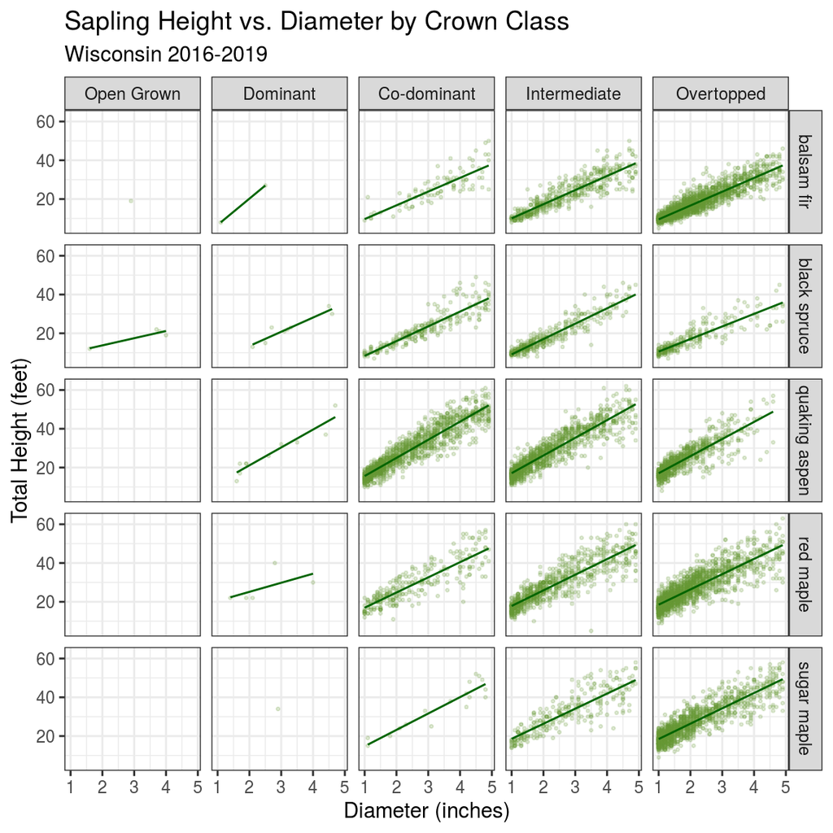

```r
ggplot()+
  geom_point(data=trees,mapping=aes(x=DIA,y=HT),size=.5,shape=21,fill="#669933",color="#669933",alpha=.2)+
  facet_grid(SPCD~CCLCD)+
  theme(strip.text=element_text(size=9))+
  scale_x_continuous(name="Diameter (inches)")+
  scale_y_continuous(name="Total Height (feet)")+
  theme_bw()+
  theme(legend.position="none")+
  geom_smooth(data=trees,mapping=aes(x=DIA,y=HT),method="lm",color="darkgreen",se=FALSE,size=.5)+
    labs(title="Sapling Height vs. Diameter by Crown Class",
       subtitle="Wisconsin 2016-2019")
```

# Crown Class 2

Of course this is just like the one above with only one species plotted. This is what I was initially going for and was pleased that I was able to figure out how to create a subset of the data. Also, the double faceted plot above helped me choose a species to focus on. I chose black spruce here because it had samples in all five crown class categories. I definitely see myself using double faceted plots as exploratory plots to help determine items of interest.

```
#R> `geom_smooth()` using formula 'y ~ x'
```

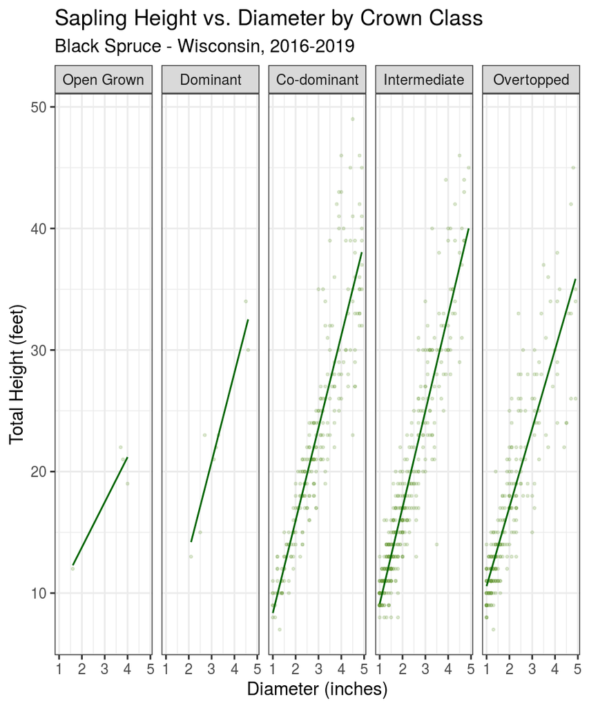

```r
ggplot()+
  geom_point(data=trees2,mapping=aes(x=DIA,y=HT),size=.5,shape=21,fill="#669933",color="#669933",alpha=.2)+
  facet_grid(.~CCLCD)+
  scale_x_continuous(name="Diameter (inches)")+
  scale_y_continuous(name="Total Height (feet)")+
  theme_bw()+
  theme(legend.position="none")+
  geom_smooth(data=trees2,mapping=aes(x=DIA,y=HT),method="lm",color="darkgreen",se=FALSE,size=.5)+
    labs(title="Sapling Height vs. Diameter by Crown Class",
       subtitle="Black Spruce - Wisconsin, 2016-2019")
```

# Looking at a violin plot

So- since my others were all so similar I thought I’d make the black spruce figure a violin plot to see what it looked like and if I could make sense of it. I’m very much against my use of colors here since if I were looking at it I would expect some meaning or legend associated with the colors- BUT- the plot looks pretty with the colors and rather boring without. I also don’t feel like this is especially useful for this particular variable because although we get a sense of the distribution of heights for each crown class, we don’t have the associated diameter data. I wouldn’t use this one but it gets me thinking…

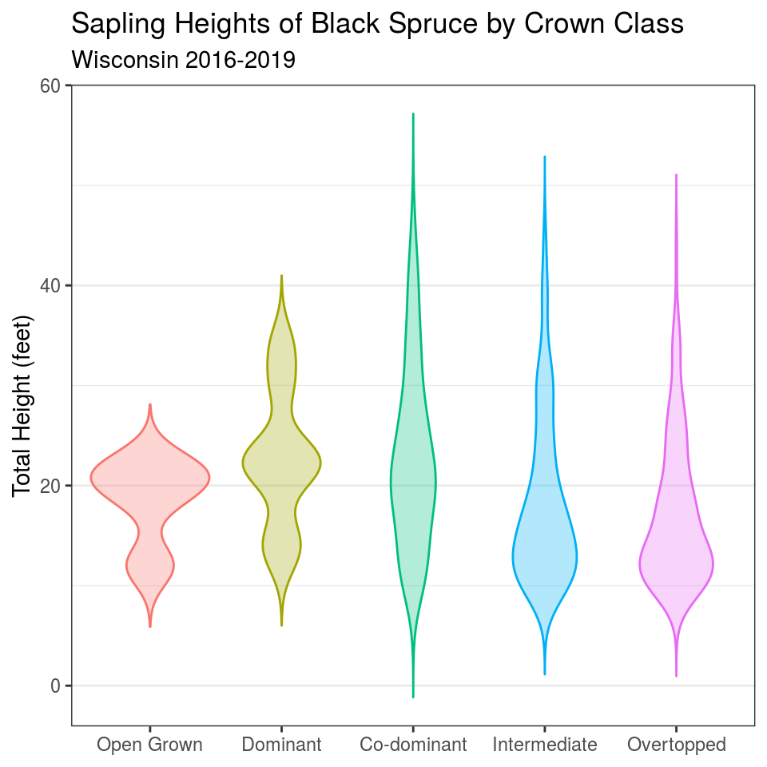

```r
ggplot()+
  geom_violin(data=trees2,mapping=aes(x=CCLCD,y=HT,color=CCLCD,fill=CCLCD),alpha=.3,trim=FALSE)+
  scale_x_discrete(name=NULL)+
  scale_y_continuous(name="Total Height (feet)")+
  theme_bw()+
  theme(panel.grid.major.x = element_blank())+
  theme(legend.position="none")+
    labs(title="Sapling Heights of Black Spruce by Crown Class",
       subtitle="Wisconsin 2016-2019")
```

# Looking for potential changes over time in the relationship between diameter vs. height in a single species in WI.

This is psychedelic! I’d need to work on this some BUT I’m excited that I think I figured out how to mutate the years into discrete values AND filter to only the years I wanted. I would need to work with colors etc on this one if I planned to use it for anything. I would also be interested in looking at various species and a broader range of diameters. I see that the regression lines diverge as the diameters increase, but I suspect that is due more to smaller sample sizes of the larger trees rather than actual differences caused by changes in growing conditions. I wanted to look at this because I was curious if we DID model for sapling height whether we might need to update our models every 10 or 20 years.  
I would have liked to look at older data from before 2000 but apparently they didn’t take total height before then. I think they took merchantable heights or some such thing.

Well- I was just trying to change the Legend name as a final detail adjustment and not having any luck. I am beginning to wonder if there is something going on here that I don’t fully understand…. More learning to be done I guess, but for now, it’s time for me to call it. Update- just forgot a plus sign! All straightened out now.

```
#R> `geom_smooth()` using formula 'y ~ x'
```

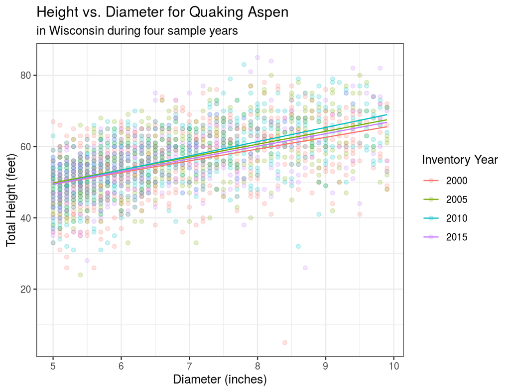

```r
ggplot(data=aspen,mapping=aes(x=DIA,y=HT,color=INVYR))+
  geom_point(alpha=0.2)+
  scale_x_continuous(name="Diameter (inches)")+
  scale_y_continuous(name="Total Height (feet)")+
  theme_bw()+
  geom_smooth(method="lm",se=FALSE,size=0.5)+
  labs(title="Height vs. Diameter for Quaking Aspen",
       subtitle="in Wisconsin during four sample years")+
  labs(color="Inventory Year")
```